# Practica 4

Murillo Alba Josué Iván

Marzo 2025

```r
library(tseries)
```

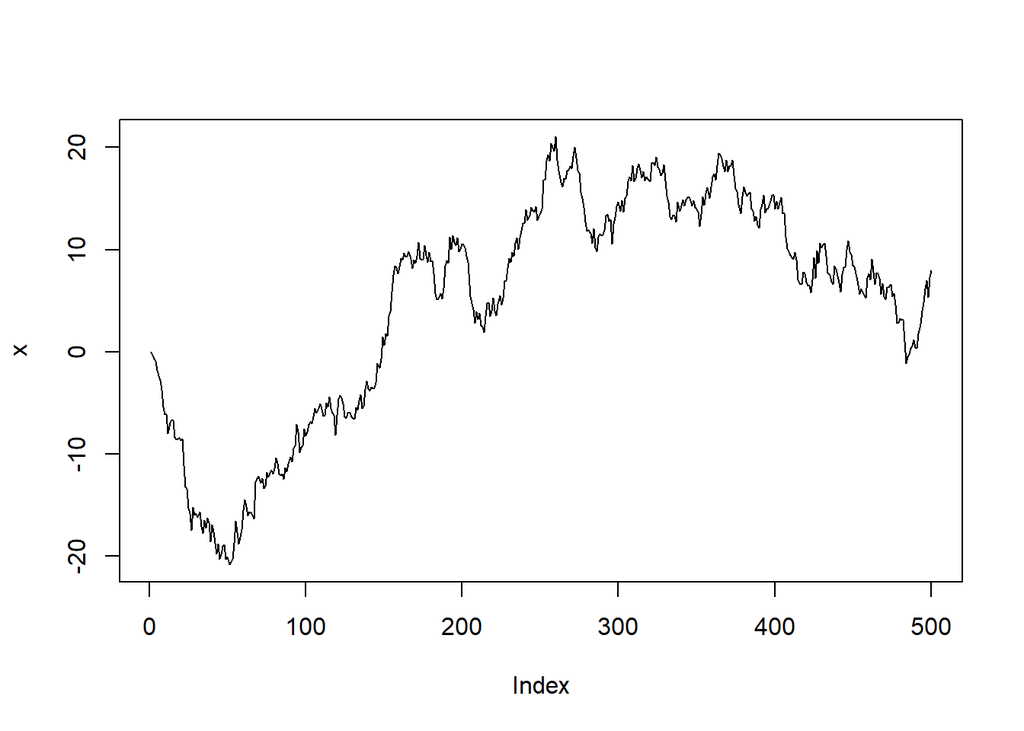

```r
n <- 500
w <- rnorm(n)
x <- numeric(n)

for(t in 2:n)
  x[t] <- x[t-1] + w[t]
plot(x, type = 'l')
```

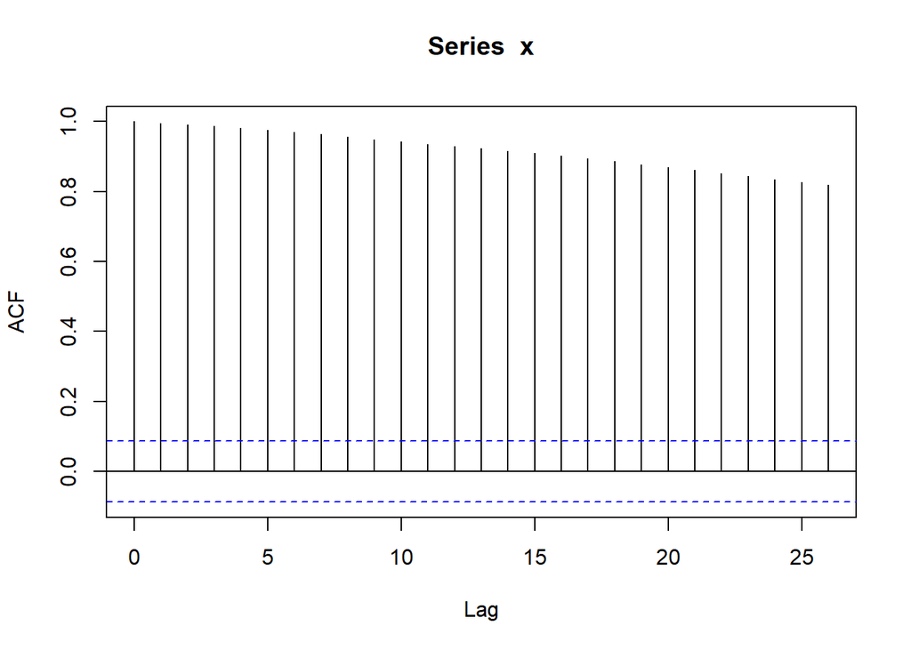

```r
acf(x)
```

```r
adf.test(x)
```

```
##
##  Augmented Dickey-Fuller Test
##
## data:  x
## Dickey-Fuller = -1.8192, Lag order = 7, p-value = 0.6548
## alternative hypothesis: stationary
```

```r
d1x <- diff(x)
adf.test(d1x)
```

```
##
##  Augmented Dickey-Fuller Test
##
## data:  d1x
## Dickey-Fuller = -6.3449, Lag order = 7, p-value = 0.01
## alternative hypothesis: stationary
```

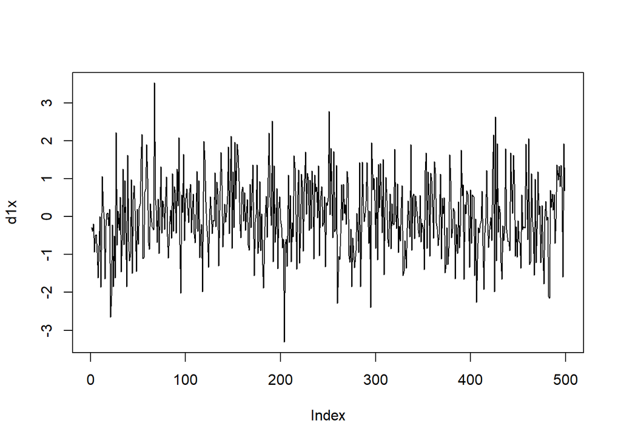

```r
plot(d1x, type = 'l')
```

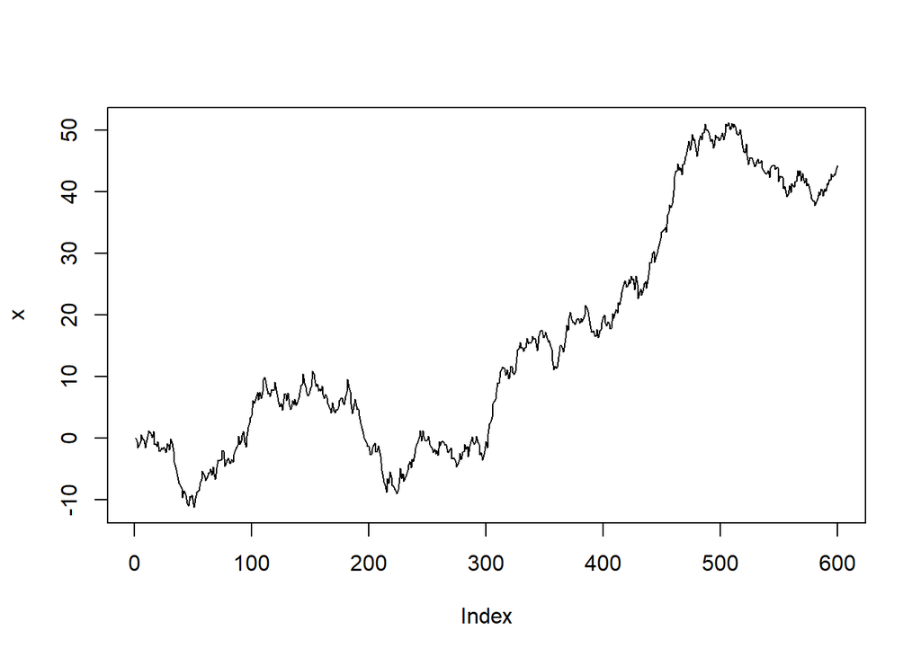

```r
n = 600
w <- rnorm(n)
x <- numeric(n)
dx <- numeric(n)

for (t in 2:n) {
  x[t] <- x[t-1] + w[t]

}

plot(x, type = 'l')
```

```r
d1x <- diff(x)

for(t in 2:n)
  dx[t] <- x[t] - x[t-1]

dx <- dx[-c(1)]

head(dx)
```

```
## [1] -0.5963958 -0.9372948  0.4633743  0.5661862  1.0644570 -0.6359468
```

```r
head(d1x)
```

```
## [1] -0.5963958 -0.9372948  0.4633743  0.5661862  1.0644570 -0.6359468
```

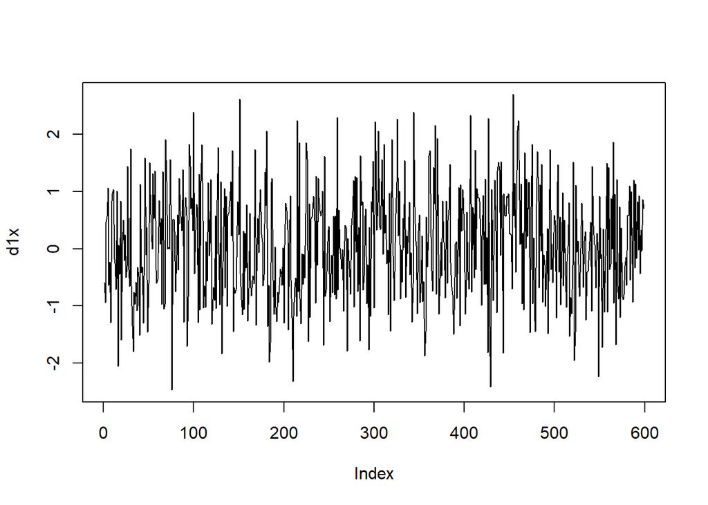

```r
plot(d1x, type = 'l')
```

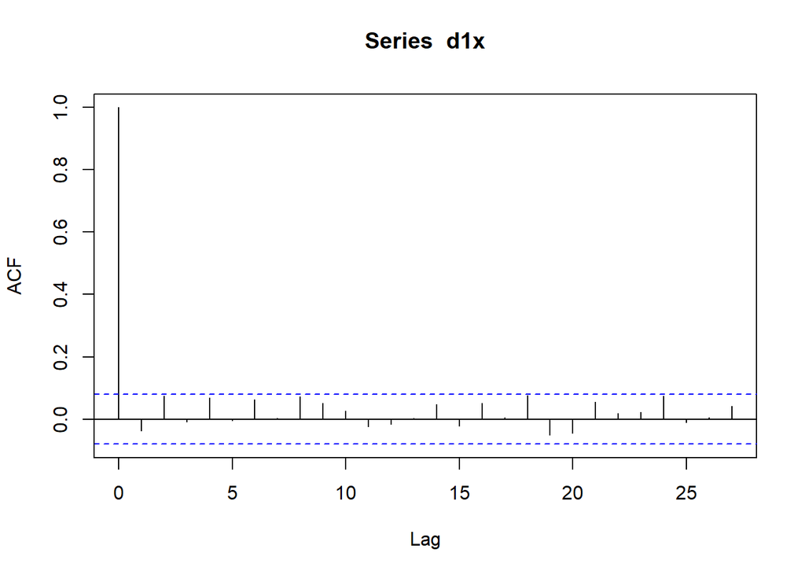

```r
acf(d1x)
```

# Series de Tiempo Integradas

1. Carga en R los datos del archivo. Los datos contienen una serie de tiempo.

```r
file1 <- read.csv('PracR.csv')
file2<- read.csv('PracT.csv')
file3<- read.csv('PracX.csv')
file4<- read.csv('PracY.csv')
```

## PracR

### b

Determina si la serie de tiempo es estacionaria o no. Realiza la gr´afica y utiliza la prueba de Dickey-Fuller Aumentada. Explica por que es o por qu´e no es estacionaria.

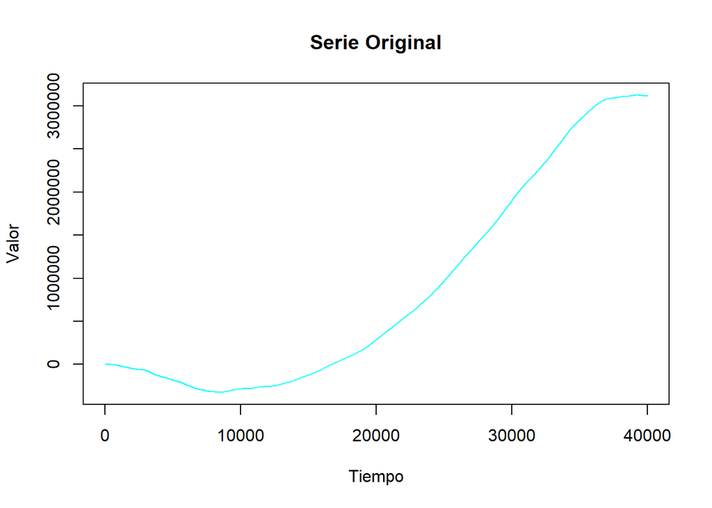

```r
x <- file1$x
n <- nrow(file1)

# Original
plot(x, type = 'l', main = "Serie Original", col = "cyan", xlab = "Tiempo", ylab = "Valor")
```

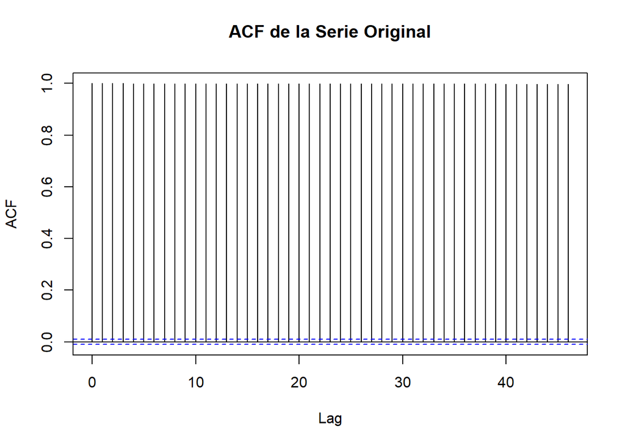

```r
acf(x, main = "ACF de la Serie Original")
```

```r
# Prueba DF
adf_result <- adf.test(x)
print(adf_result)
```

```
##
##  Augmented Dickey-Fuller Test
##
## data:  x
## Dickey-Fuller = -2.8317, Lag order = 34, p-value = 0.2251
## alternative hypothesis: stationary
```

Reglas Clave en Pruebas de Estacionariedad Valor-p (p-value) - Si `p-value < 0.05` → Rechazas la hipótesis nula (*H0*).  
**Conclusión:** La serie es estacionaria.  
- Si `p-value ≥ 0.05` → No rechazas *H0*.  
**Conclusión:** La serie NO es estacionaria (tiene raíz unitaria).

Estadístico de Dickey-Fuller vs. Valores Críticos Compara el estadístico Dickey-Fuller (`−2.8317`) con los valores críticos típicos:  
- **1%:** `−3.43`  
- **5%:** `−2.86`  
- **10%:** `−2.57`  
- Si el estadístico es menor (más negativo) que el valor crítico → Rechazas *H0*.  
- Si el estadístico es mayor (menos negativo) que el valor crítico → No rechazas *H0*.

Lag Order (Rezagos) El **Lag order** (`34`) indica el número de rezagos usados para modelar la autocorrelación.  
- Si el *Lag order* es muy alto en comparación con el tamaño de la serie, la prueba puede perder potencia.  
- Verifica que el número de observaciones (*n*) sea mayor que `Lag order + 20`.

En nuestro caso: Notamos que la grafica tiene una tendencia postiva o que incrementa a lo largo de los momentos con la prueba de DF tenemos que

Valor-p - `0.2251 > 0.05`  
**Conclusión:** No estacionaria.

Estadístico Dickey-Fuller - `−2.8317 > −2.86` (valor crítico al 5%)  
**Conclusión:** No estacionaria.

Lag Order 20 + 34 < 40002 aceptable

### c

Convierte la serie de tiempo en una serie de tiempo estacionaria. Explica tu procedimiento.

```r
# Diferenciar
d1x <- diff(x)
adf.test(d1x)
```

```
##
##  Augmented Dickey-Fuller Test
##
## data:  d1x
## Dickey-Fuller = -0.16721, Lag order = 34, p-value = 0.99
## alternative hypothesis: stationary
```

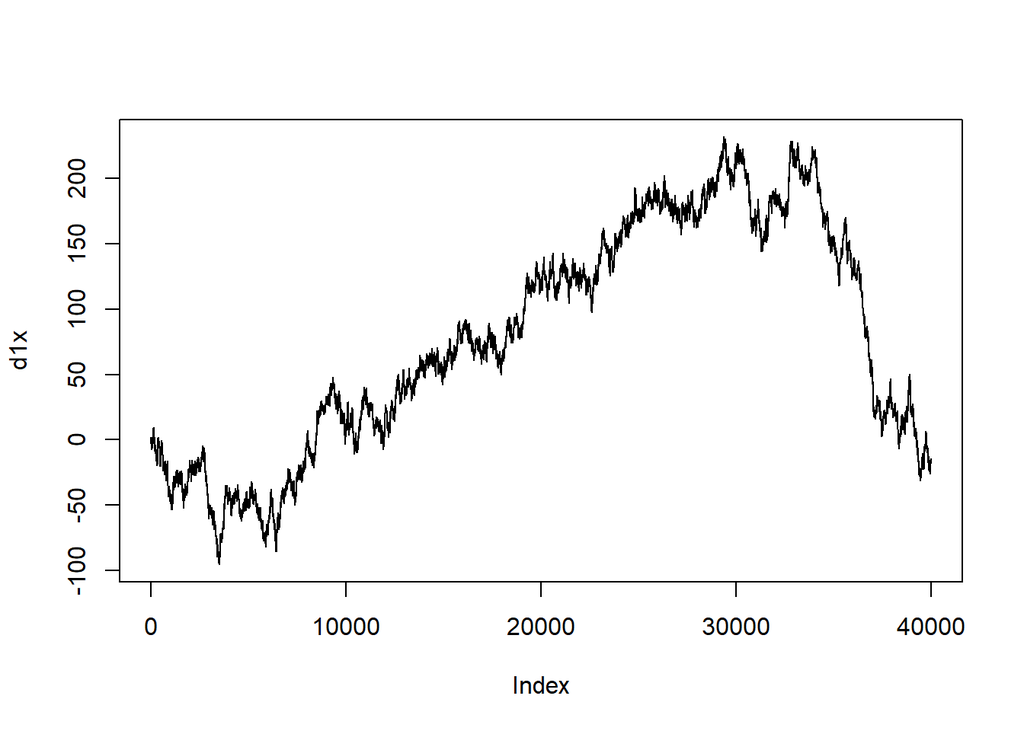

```r
plot(d1x, type = 'l')
```

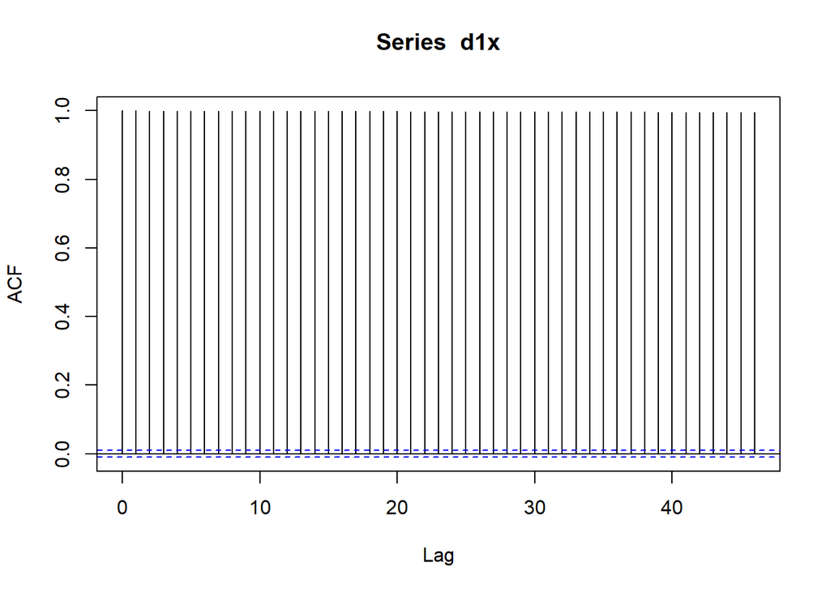

```r
acf(d1x)
```

```r
# Diferencia 2
d2x <- diff(d1x)
adf.test(d2x)
```

```
##
##  Augmented Dickey-Fuller Test
##
## data:  d2x
## Dickey-Fuller = -33.504, Lag order = 34, p-value = 0.01
## alternative hypothesis: stationary
```

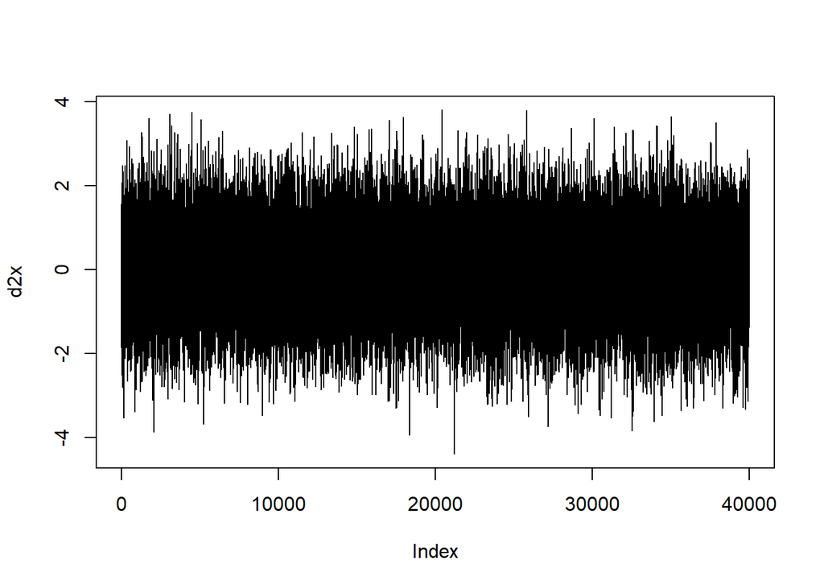

```r
plot(d2x, type = 'l')
```

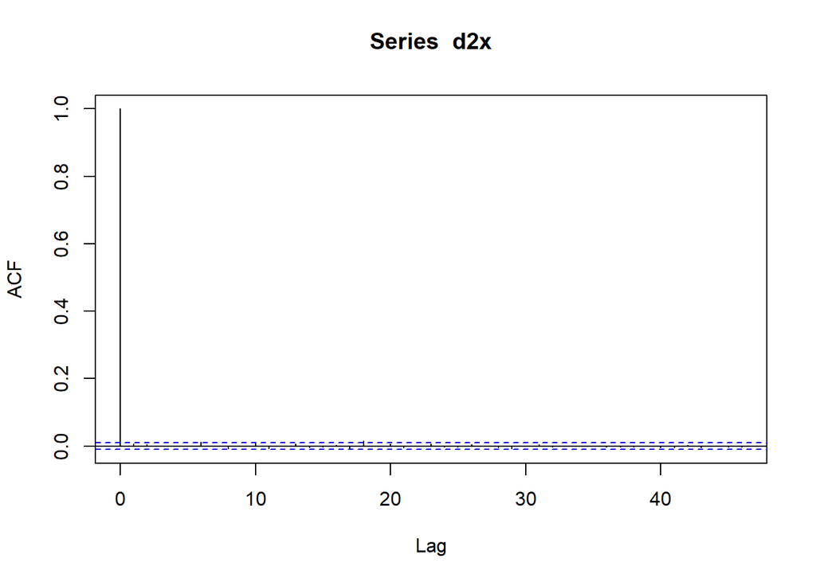

```r
acf(d2x)
```

primero observamos con una diferencia que los elementos estadisticos no se reflejan ya que no tiene una tendencia fija y sigue teniendo una tendcencia o positiva o negativa ademas la correlaccion tiene bastantes retrasos y que caen de manera muy lenta, cuando aplilcamos la segunda diferencia observamos directamente por sus graficas que tiene una tendencia fija y su correlacion solo se puede observar un retraso y por los indicadores tenemos: Valor-p - `0.01<0.05`  
**Conclusión:** estacionaria.

Estadístico Dickey-Fuller - -33.504< -2.86 **Conclusión:** estacionaria.

### d

Concluye que la serie es integrada de orden d, I(d). ¿Cu´al es el valor de d?

Valor de d El valor de d (orden de integración) es **2**, por lo que la serie es **I(2)**.

Serie Original (I(0)) - **No estacionaria:** - ADF test: `p-value = 0.2251 > 0.05`, `Dickey-Fuller = -2.83 > -2.86` (valor crítico al 5%). - Gráfica y ACF muestran tendencia y correlación persistente.

Primera Diferencia (I(1)) - **Sigue sin ser estacionaria:**

Segunda Diferencia (I(2)) - **Estacionaria:** - ADF test: `p-value = 0.01 < 0.05`, `Dickey-Fuller = -33.504 < -2.86`. - Gráfica sin tendencia y ACF con decaimiento rápido.

Conclusión Final La serie original requiere 2 diferenciaciones para volverse estacionaria, por lo que es integrada de orden **2**, denotada como **I(2)**.

Fórmula de Integración

$$\nabla^2 x_t = (1 - L)^2 x_t = x_t - 2x_{t-1} + x_{t-2}$$

Donde:  
- $\nabla$ es el operador de diferencia.  
- $L$ es el operador de rezago.

## PracT

### b

Determina si la serie de tiempo es estacionaria o no. Realiza la grafica y utiliza la prueba de Dickey-Fuller Aumentada. Explica por que es o por qu´e no es estacionaria.

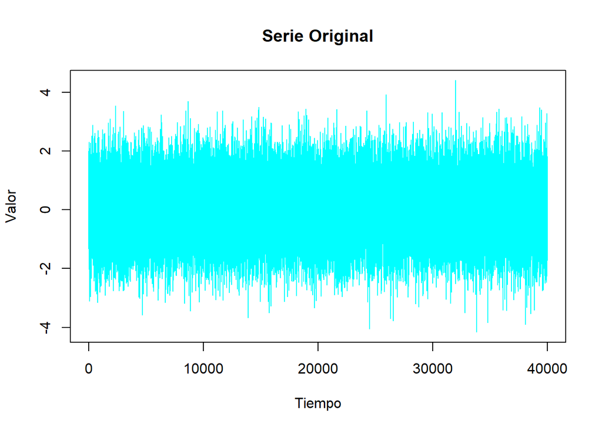

```r
x <- file2$x
n <- nrow(file2)

# Original
plot(x, type = 'l', main = "Serie Original", col = "cyan", xlab = "Tiempo", ylab = "Valor")
```

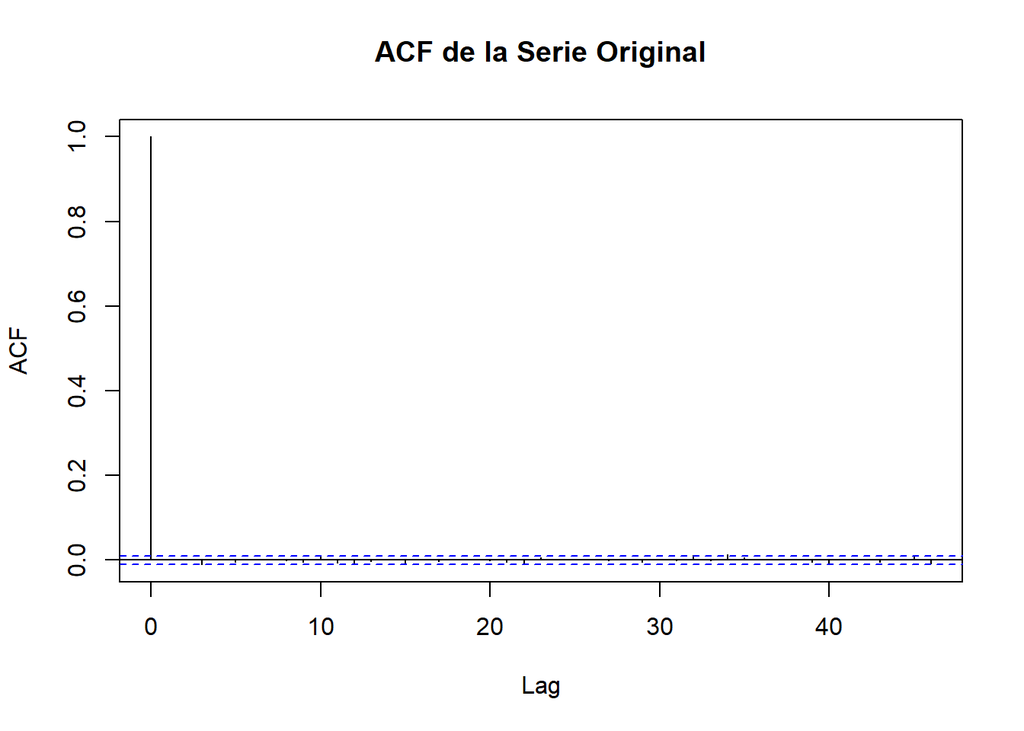

```r
acf(x, main = "ACF de la Serie Original")
```

```r
# Prueba DF
adf_result <- adf.test(x)
print(adf_result)
```

```
##
##  Augmented Dickey-Fuller Test
##
## data:  x
## Dickey-Fuller = -33.379, Lag order = 34, p-value = 0.01
## alternative hypothesis: stationary
```

En nuestro caso: Es estacionaria, si observamos las graficas vemos que esta tiene una tendencia fija a lo largo del eje x, la grafica de correlacion los retrasos caen rapidamente y por las pruebas tenemos que

Dickey-Fuller = -33.379, Lag order = 34, p-value = 0.01

Valor-p - `0.01 < 0.05`  
**Conclusión:** estacionaria.

Estadístico Dickey-Fuller - `-33.379 < −2.86` (valor crítico al 5%)  
**Conclusión:** estacionaria.

## PracX

### b

Determina si la serie de tiempo es estacionaria o no. Realiza la gr´afica y utiliza la prueba de Dickey-Fuller Aumentada. Explica por que es o por qu´e no es estacionaria.

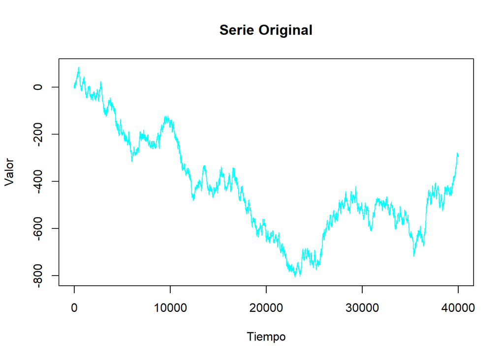

```r
x <- file3$x
n <- nrow(file3)

# Original
plot(x, type = 'l', main = "Serie Original", col = "cyan", xlab = "Tiempo", ylab = "Valor")
```

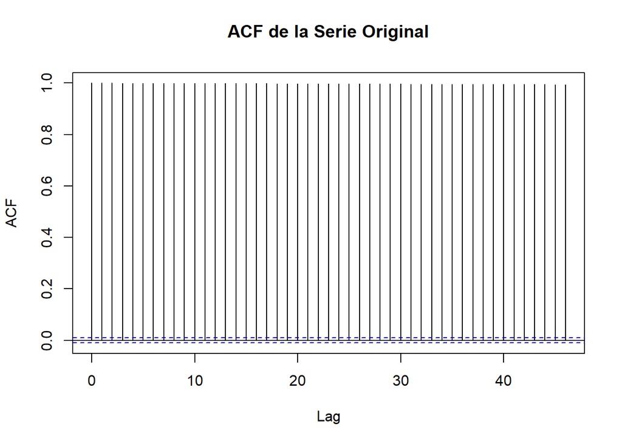

```r
acf(x, main = "ACF de la Serie Original")
```

```r
# Prueba DF
adf_result <- adf.test(x)
print(adf_result)
```

```
##
##  Augmented Dickey-Fuller Test
##
## data:  x
## Dickey-Fuller = -0.81458, Lag order = 34, p-value = 0.9607
## alternative hypothesis: stationary
```

En nuestro caso: Notamos que la grafica tiene una tendencia negaiva o que decrementa a lo largo de los momentos con la prueba de DF tenemos que

Dickey-Fuller = -0.81458, Lag order = 34, p-value = 0.9607

Valor-p - `0.9607 > 0.05`  
**Conclusión:** No estacionaria.

Estadístico Dickey-Fuller - `-0.81458 > −2.86` (valor crítico al 5%)  
**Conclusión:** No estacionaria.

### c

Convierte la serie de tiempo en una serie de tiempo estacionaria. Explica tu procedimiento.

```r
# Diferenciar
d1x <- diff(x)
adf.test(d1x)
```

```
##
##  Augmented Dickey-Fuller Test
##
## data:  d1x
## Dickey-Fuller = -31.576, Lag order = 34, p-value = 0.01
## alternative hypothesis: stationary
```

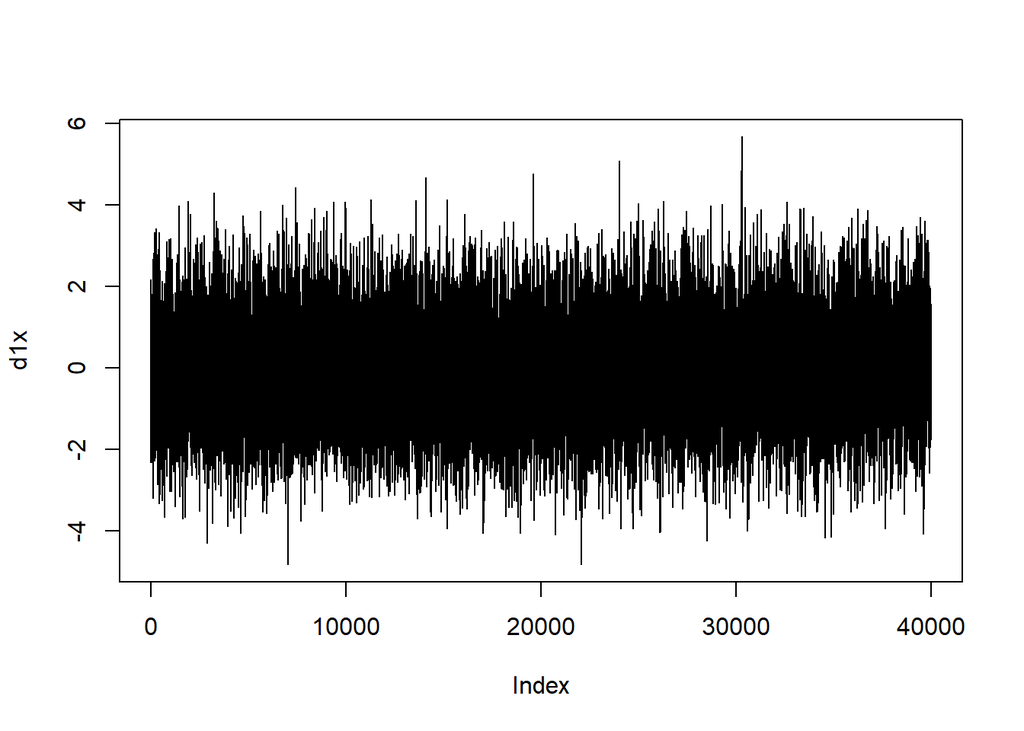

```r
plot(d1x, type = 'l')
```

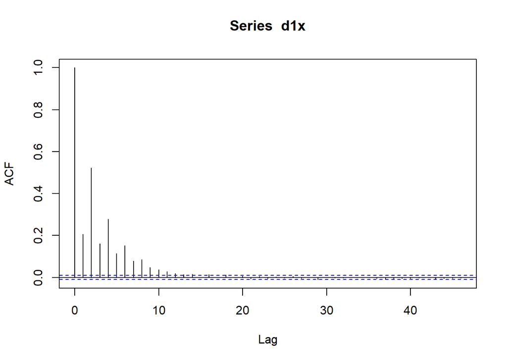

```r
acf(d1x)
```

Ciuando aplicamod la priemera diferencia observamos directamente por sus graficas que tiene una tendencia fija y su correlacion se observa que los retrasos caen rapidamente, con los indicadores tenemos que:

Valor-p - `0.01<0.05`  
**Conclusión:** estacionaria.

Estadístico Dickey-Fuller - -31.576< -2.86 **Conclusión:** estacionaria.

### d

Concluye que la serie es integrada de orden d, I(d). ¿Cu´al es el valor de d?

Valor de d El valor de d (orden de integración) es **1**, por lo que la serie es **I(1)**.

Dickey-Fuller = -0.81458, Lag order = 34, p-value = 0.9607

Serie Original (I(0)) - **No estacionaria:** - ADF test: `p-value = 0.9607 > 0.05`, `Dickey-Fuller = -0.81458 > -2.86` (valor crítico al 5%). - Gráfica y ACF muestran tendencia y correlación persistente.

Primera Diferencia (I(1)) - **Estacionaria:** - Gráfica sin tendencia y ACF con decaimiento rápido.

Conclusión Final La serie original requiere 1 diferenciaciones para volverse estacionaria, por lo que es integrada de orden **1**, denotada como **I(1)**.

## PracY

### b

Determina si la serie de tiempo es estacionaria o no. Realiza la gr´afica y utiliza la prueba de Dickey-Fuller Aumentada. Explica por que es o por qu´e no es estacionaria.

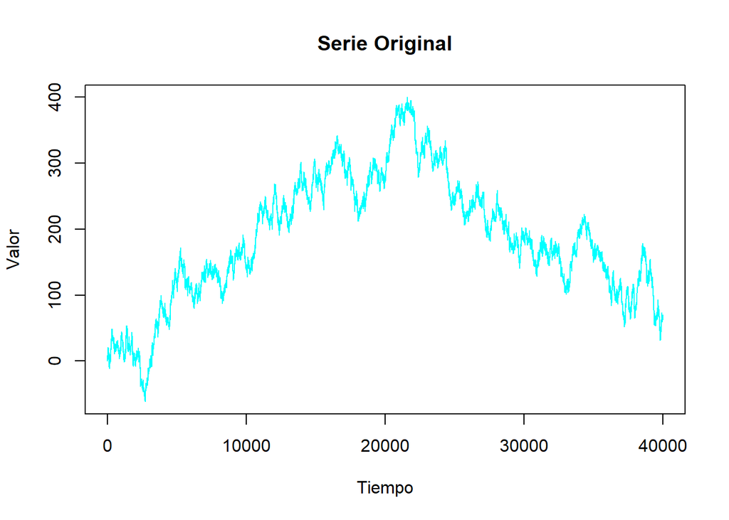

```r
x <- file4$x
n <- nrow(file4)

# Original
plot(x, type = 'l', main = "Serie Original", col = "cyan", xlab = "Tiempo", ylab = "Valor")
```

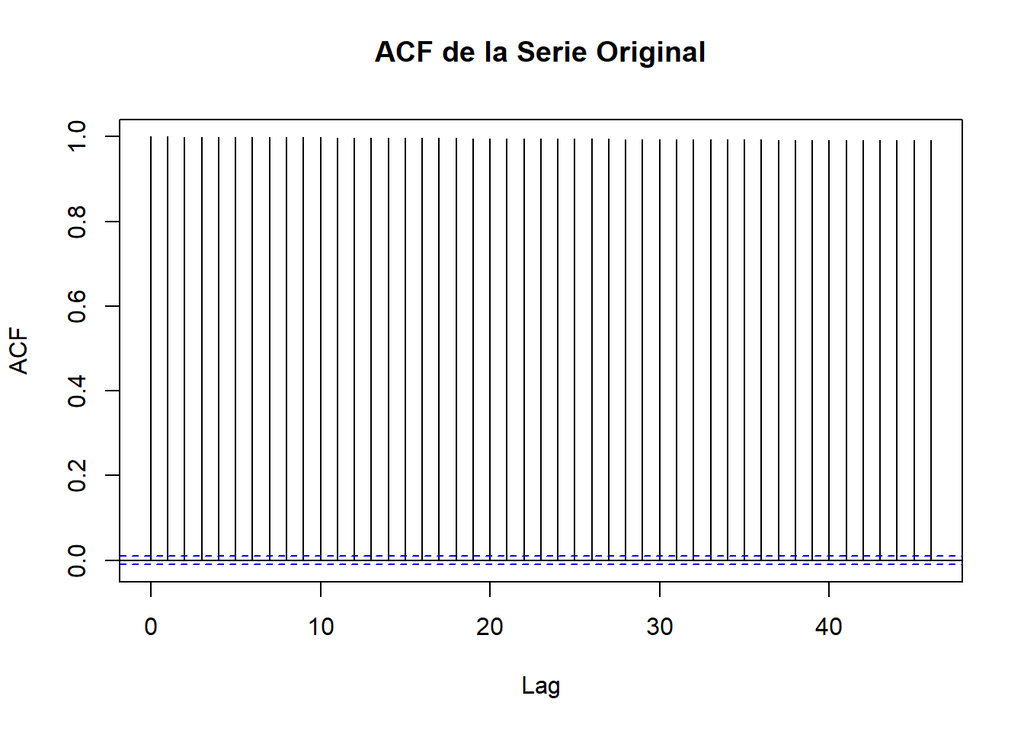

```r
acf(x, main = "ACF de la Serie Original")
```

```r
# Prueba DF
adf_result <- adf.test(x)
print(adf_result)
```

```
##
##  Augmented Dickey-Fuller Test
##
## data:  x
## Dickey-Fuller = -1.5551, Lag order = 34, p-value = 0.7677
## alternative hypothesis: stationary
```

En nuestro caso: Se observa que la grafica no tiene una tendencia fija va de arriba hacia abajo y la grafica de correlacion los retrasos parecen que son constantes.

Dickey-Fuller = -1.5551, Lag order = 34, p-value = 0.7677

Valor-p - `0.7677 > 0.05`  
**Conclusión:** No estacionaria.

Estadístico Dickey-Fuller - `-1.5551 > −2.86` (valor crítico al 5%)  
**Conclusión:** No estacionaria.

### c

Convierte la serie de tiempo en una serie de tiempo estacionaria. Explica tu procedimiento.

```r
# Diferenciar
d1x <- diff(x)
adf.test(d1x)
```

```
##
##  Augmented Dickey-Fuller Test
##
## data:  d1x
## Dickey-Fuller = -33.651, Lag order = 34, p-value = 0.01
## alternative hypothesis: stationary
```

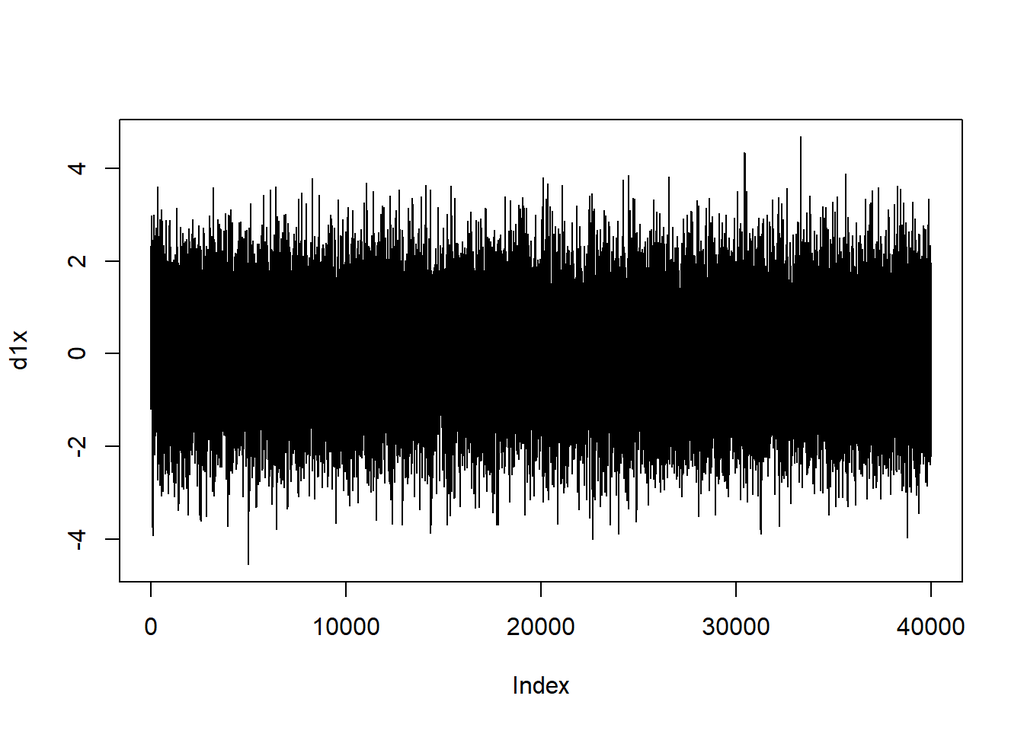

```r
plot(d1x, type = 'l')
```

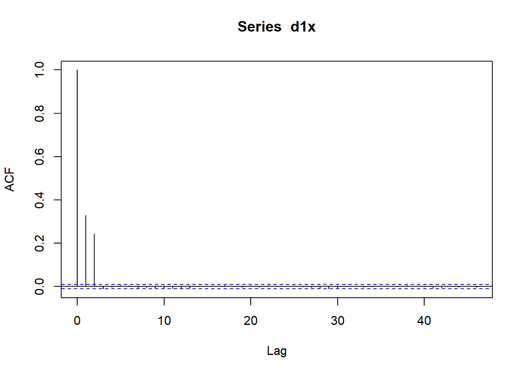

```r
acf(d1x)
```

Ciuando aplicamod la priemera diferencia observamos directamente por sus graficas que tiene una tendencia fija y su correlacion se observa que los retrasos caen rapidamente, con los indicadores tenemos que:

Dickey-Fuller = -33.651, Lag order = 34, p-value = 0.01

Valor-p - `0.01<0.05`  
**Conclusión:** estacionaria.

Estadístico Dickey-Fuller - -33.651< -2.86 **Conclusión:** estacionaria.

### d

Concluye que la serie es integrada de orden d, I(d). ¿Cu´al es el valor de d?

Valor de d El valor de d (orden de integración) es **1**, por lo que la serie es **I(1)**.

Serie Original (I(0)) - **No estacionaria:** - Gráfica y ACF muestran tendencia y correlación persistente.

Primera Diferencia (I(1)) - **Estacionaria:** - Gráfica sin tendencia y ACF con decaimiento rápido.

Conclusión Final La serie original requiere 1 diferenciaciones para volverse estacionaria, por lo que es integrada de orden **1**, denotada como **I(1)**.

# Parte 2

## A

Xt = 2Xt−1 − Xt−2 + .2Wt−1 + .3Wt−2 + Wt

### a

Determina si la serie de tiempo es estacionaria o no. Realiza la gr´afica y utiliza la prueba de Dickey-Fuller Aumentada. Explica por qu´e es o por qu´e no es estacionaria.

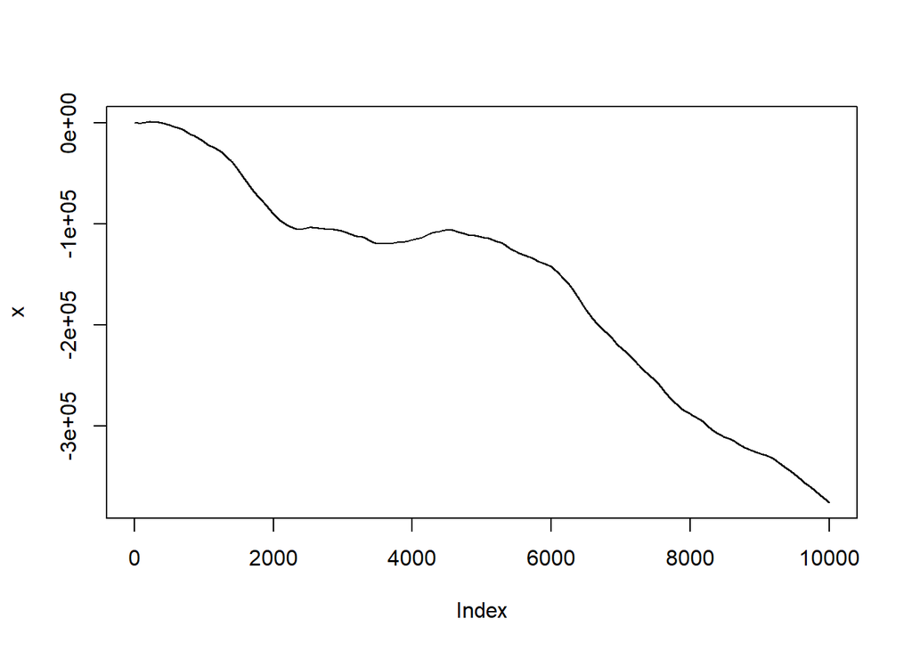

```r
n = 1e4
w <- rnorm(n)
x <- numeric(n)

for (t in 3:n) {
  x[t] <- 2*x[t-1] - x[t-2] + 0.2*w[t-1] + 0.3*w[t-2] + w[t]

}

plot(x, type = 'l')
```

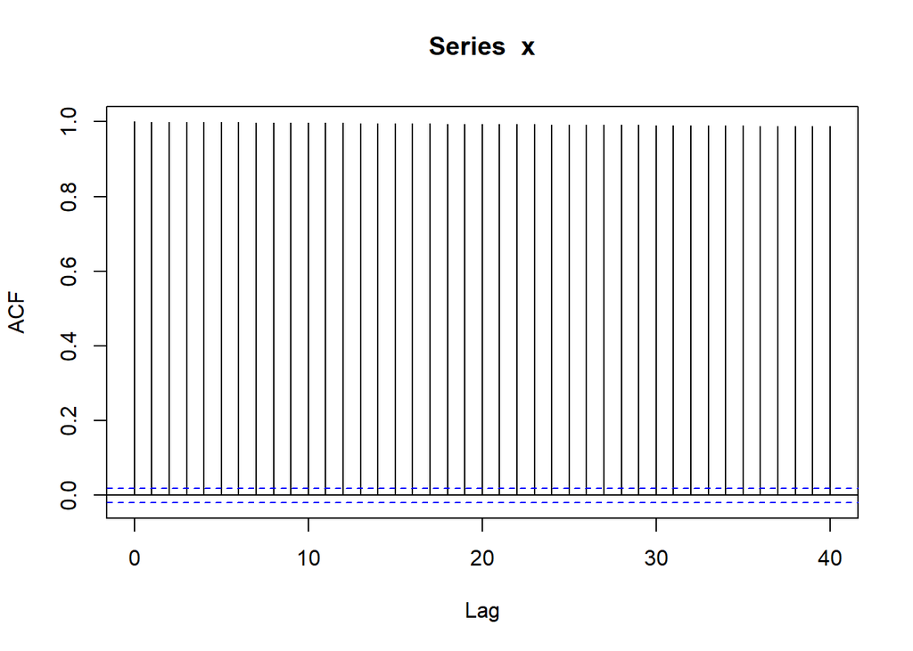

```r
acf(x)
```

```r
adf.test(x)
```

```
##
##  Augmented Dickey-Fuller Test
##
## data:  x
## Dickey-Fuller = -1.8057, Lag order = 21, p-value = 0.6607
## alternative hypothesis: stationary
```

### b

Convierte la serie de tiempo en una serie de tiempo estacionaria. Explica tu procedimiento.

```r
d1x <- diff(x)
adf.test(d1x)
```

```
##
##  Augmented Dickey-Fuller Test
##
## data:  d1x
## Dickey-Fuller = -2.5042, Lag order = 21, p-value = 0.3648
## alternative hypothesis: stationary
```

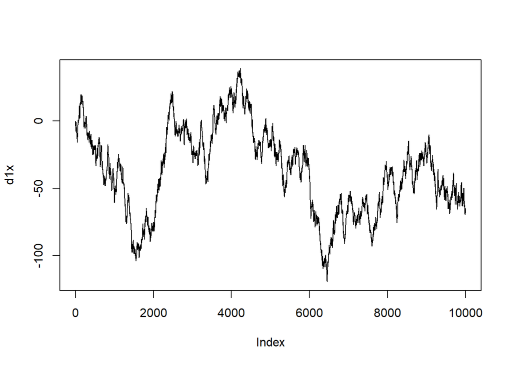

```r
plot(d1x, type = 'l')
```

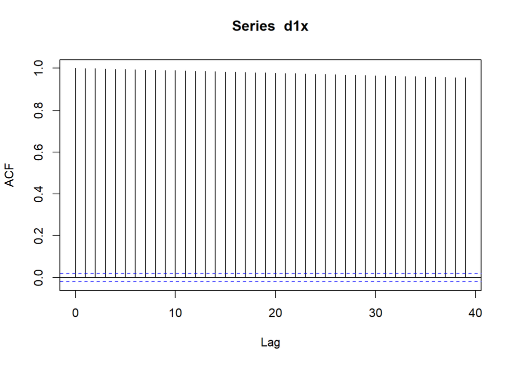

```r
acf(d1x)
```

```r
d2x <- diff(d1x)
adf.test(d2x)
```

```
##
##  Augmented Dickey-Fuller Test
##
## data:  d2x
## Dickey-Fuller = -20.897, Lag order = 21, p-value = 0.01
## alternative hypothesis: stationary
```

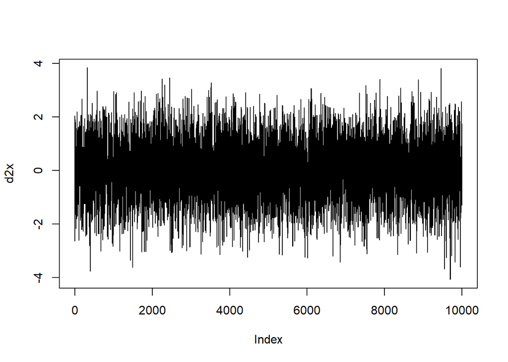

```r
plot(d2x, type = 'l')
```

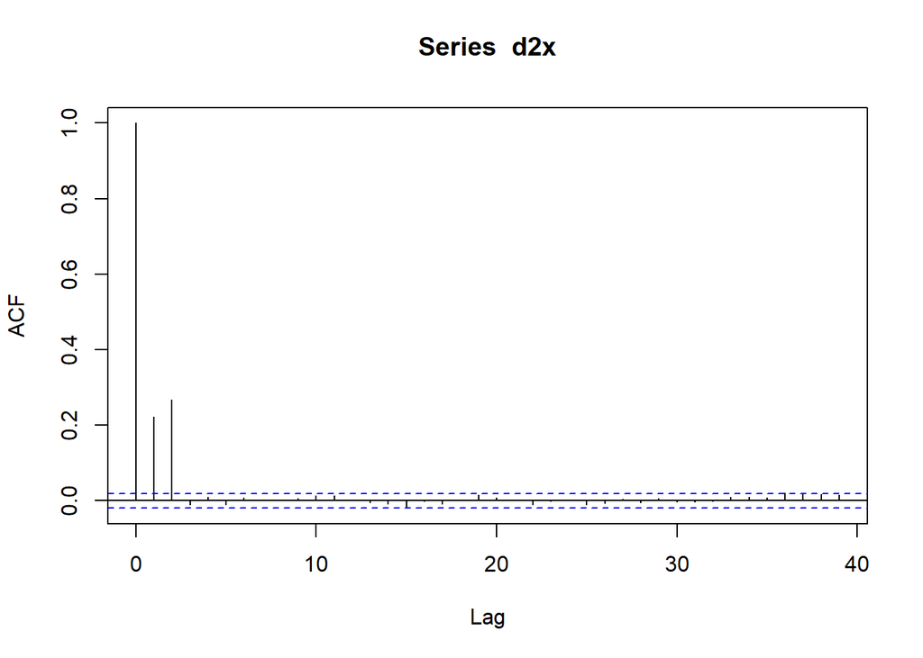

```r
acf(d2x)
```

### c

3. Concluye que la serie es integrada de orden d, I(d). ¿Cu´al es el valor de d?

La serie original requiere 2 diferenciaciones para volverse estacionaria, por lo que es integrada de orden **2**, denotada como **I(2)**

## B

Xt = 3Xt−1 − 3Xt−2 + Xt−3 + Wt

### a

Determina si la serie de tiempo es estacionaria o no. Realiza la gr´afica y utiliza la prueba de Dickey-Fuller Aumentada. Explica por qu´e es o por qu´e no es estacionaria.

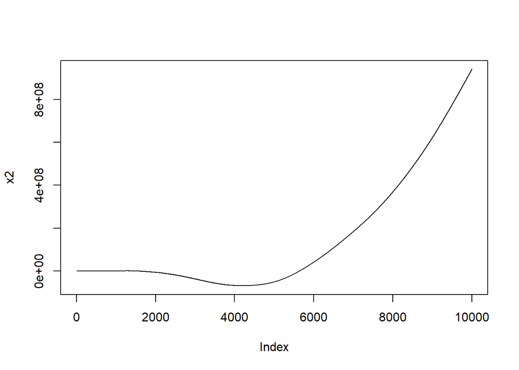

```r
n = 1e4
w <- rnorm(n)
x2 <- numeric(n)

for (t in 4:n) {
  x2[t] <- 3*x2[t-1] - 3*x2[t-2] + x2[t-3] + w[t]

}

plot(x2, type = 'l')
```

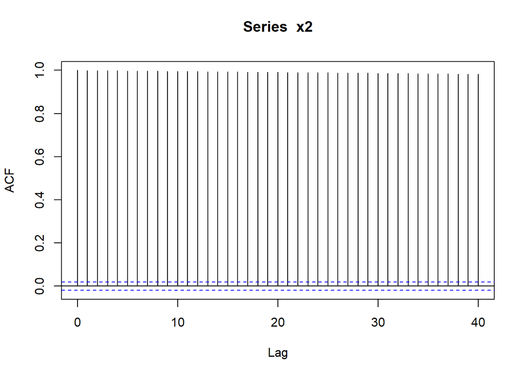

```r
acf(x2)
```

```r
adf.test(x2)
```

```
##
##  Augmented Dickey-Fuller Test
##
## data:  x2
## Dickey-Fuller = 0.29847, Lag order = 21, p-value = 0.99
## alternative hypothesis: stationary
```

podemos ver que la grafica tiene una tendencia, por la grafica de autocorrelacion observamos que los picos o los retrasos decrecen muy lento o se mantienen constantes a lo largo de los momentos y por la prueba podemos ver que p es 0.99 > 0.05 por tanto no estacionario

### b

Convierte la serie de tiempo en una serie de tiempo estacionaria. Explica tu procedimiento.

```r
d1x2 <- diff(x2)
adf.test(d1x2)
```

```
##
##  Augmented Dickey-Fuller Test
##
## data:  d1x2
## Dickey-Fuller = -2.6402, Lag order = 21, p-value = 0.3071
## alternative hypothesis: stationary
```

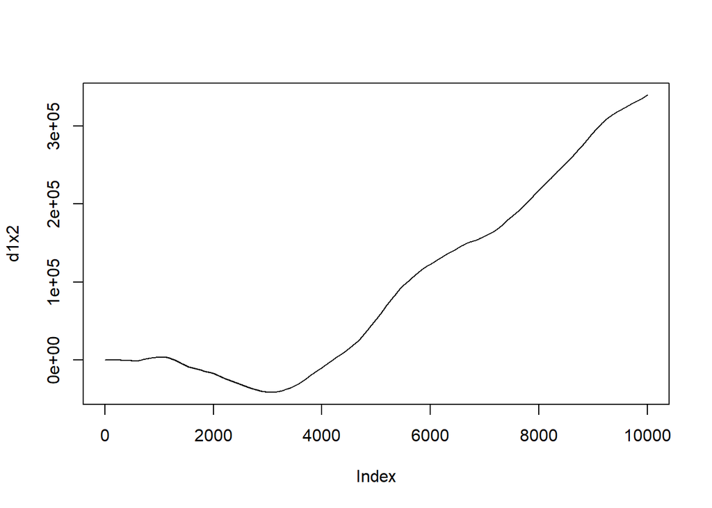

```r
plot(d1x2, type = 'l')
```

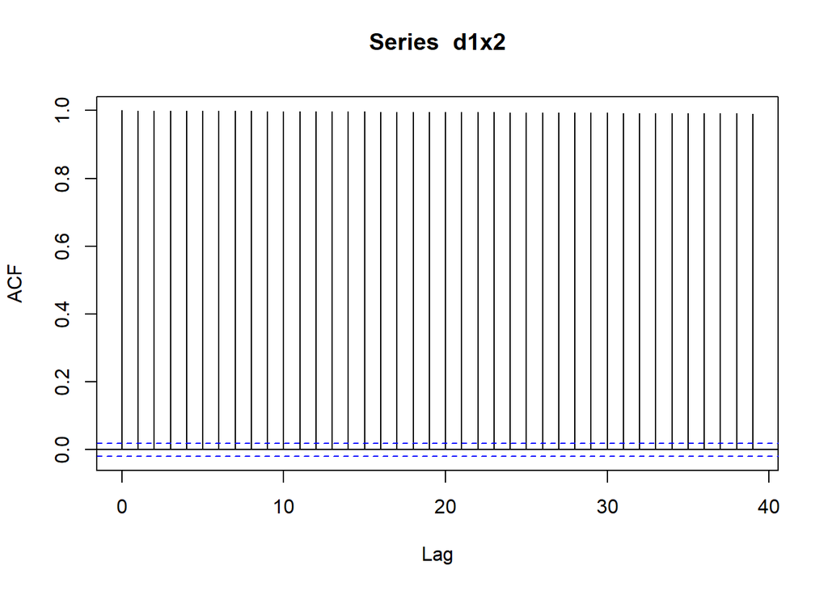

```r
acf(d1x2)
```

```r
d2x2 <- diff(d1x2)
adf.test(d2x2)
```

```
##
##  Augmented Dickey-Fuller Test
##
## data:  d2x2
## Dickey-Fuller = -1.592, Lag order = 21, p-value = 0.7513
## alternative hypothesis: stationary
```

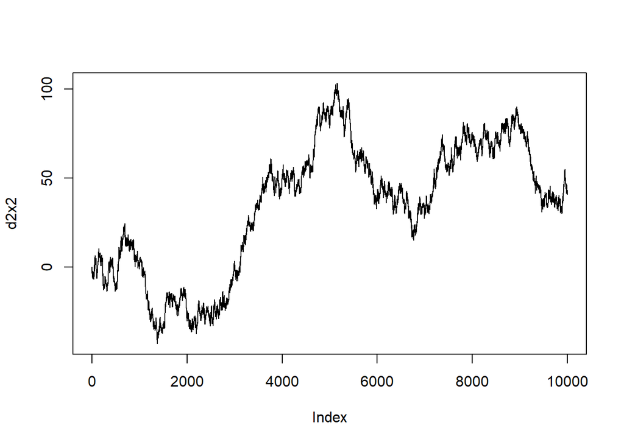

```r
plot(d2x2, type = 'l')
```

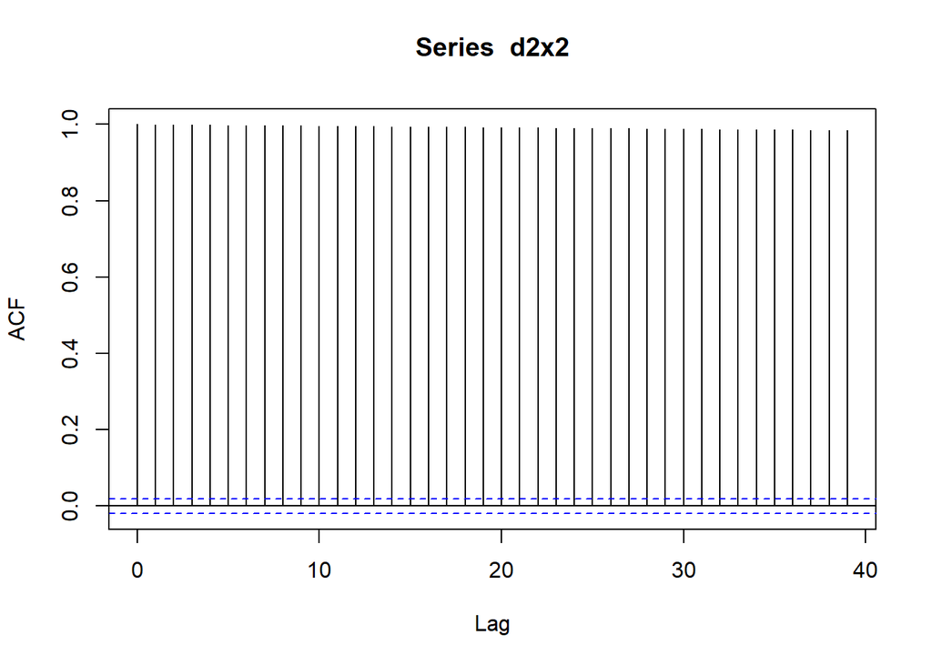

```r
acf(d2x2)
```

```r
d3x2 <- diff(d2x2)
adf.test(d3x2)
```

```
##
##  Augmented Dickey-Fuller Test
##
## data:  d3x2
## Dickey-Fuller = -21.312, Lag order = 21, p-value = 0.01
## alternative hypothesis: stationary
```

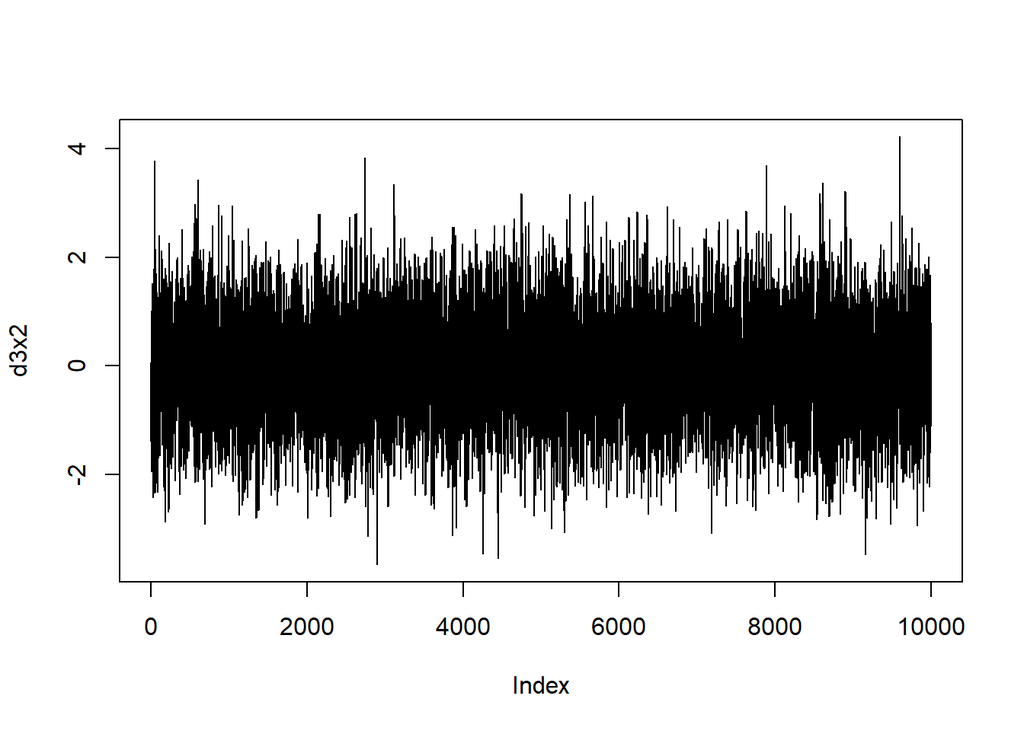

```r
plot(d3x2, type = 'l')
```

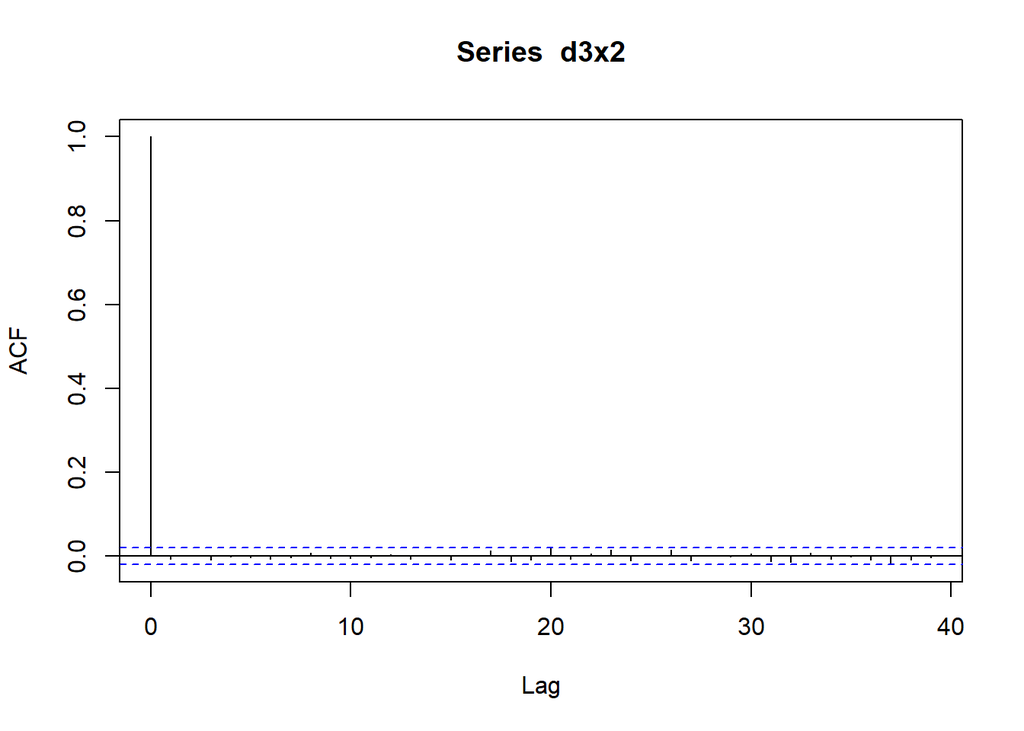

```r
acf(d3x2)
```

primero la diferenciamos una vez, observamos que la grafica sigue teniendo una tendencia y su autocorrelacion decrece lentamente, hasta cuandeo aplicamos una tercera diferencia la grafica esta dentro de un rango su autocorrelacion decae rapidamente y por la prueba tenemos que p es 0.01 < 0.05 por tanto estacionario

### c

3. Concluye que la serie es integrada de orden d, I(d). ¿Cu´al es el valor de d?

La serie original requiere 3 diferenciaciones para volverse estacionaria, por lo que es integrada de orden **3**, denotada como **I(3)**

## c

Xt = Xt−1 + .1Wt−1 + .5Wt−3 + Wt

### a

Determina si la serie de tiempo es estacionaria o no. Realiza la gr´afica y utiliza la prueba de Dickey-Fuller Aumentada. Explica por qu´e es o por qu´e no es estacionaria.

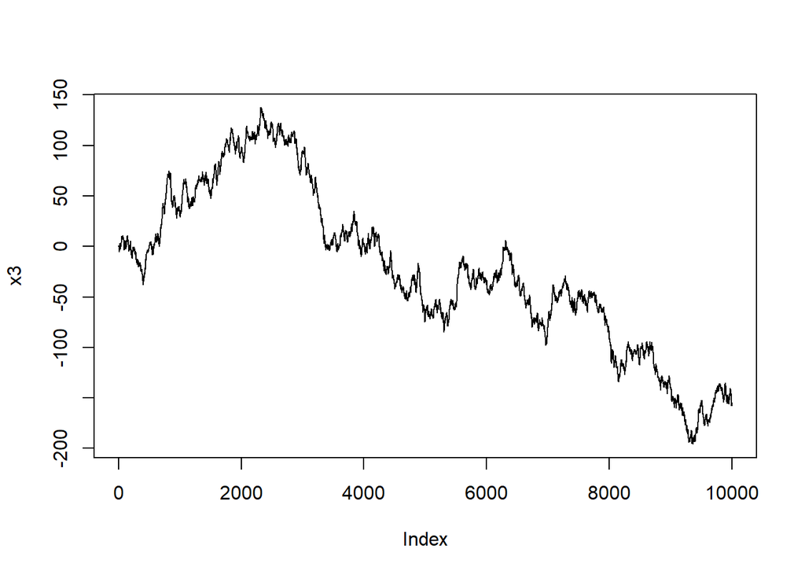

```r
n = 1e4
w <- rnorm(n)
x3 <- numeric(n)

for (t in 4:n) {
  x3[t] <- x3[t-1] + 0.1*w[t-1] + 0.5*w[t-3] + w[t]

}

plot(x3, type = 'l')
```

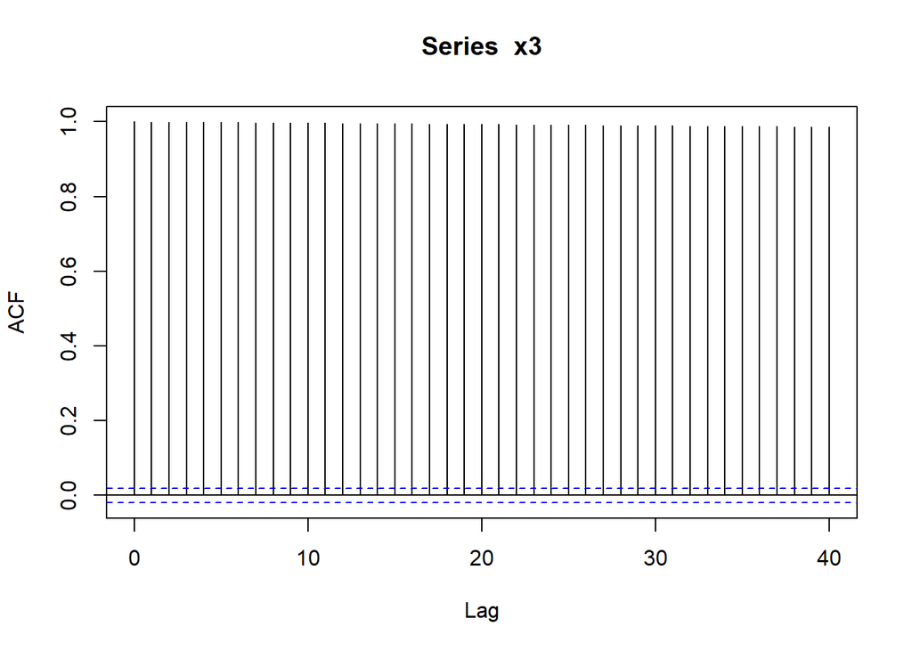

```r
acf(x3)
```

```r
adf.test(x3)
```

```
##
##  Augmented Dickey-Fuller Test
##
## data:  x3
## Dickey-Fuller = -2.6771, Lag order = 21, p-value = 0.2915
## alternative hypothesis: stationary
```

### b

Convierte la serie de tiempo en una serie de tiempo estacionaria. Explica tu procedimiento.

```r
d1x3 <- diff(x3)
adf.test(d1x3)
```

```
##
##  Augmented Dickey-Fuller Test
##
## data:  d1x3
## Dickey-Fuller = -19.892, Lag order = 21, p-value = 0.01
## alternative hypothesis: stationary
```

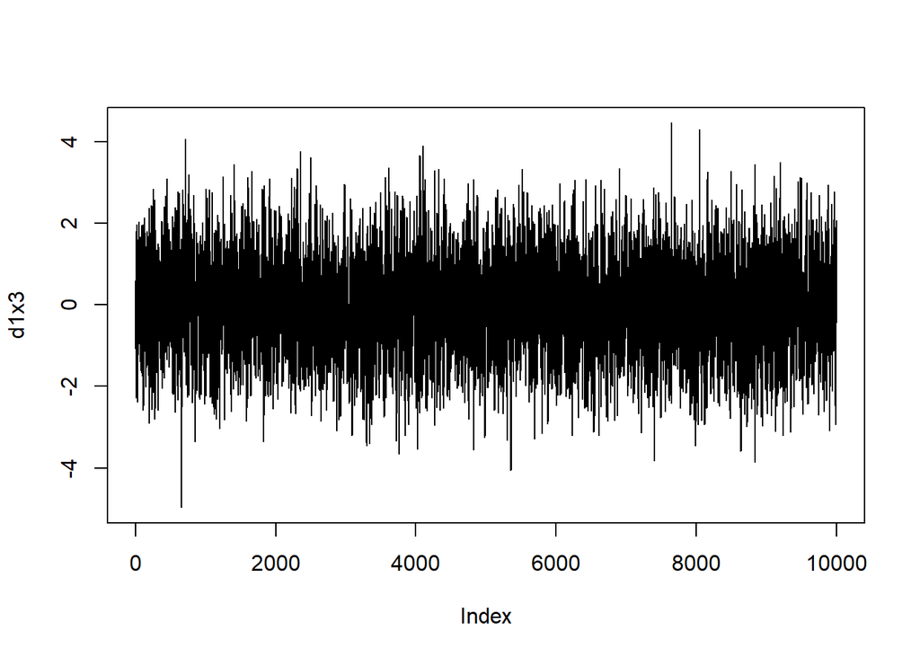

```r
plot(d1x3, type = 'l')
```

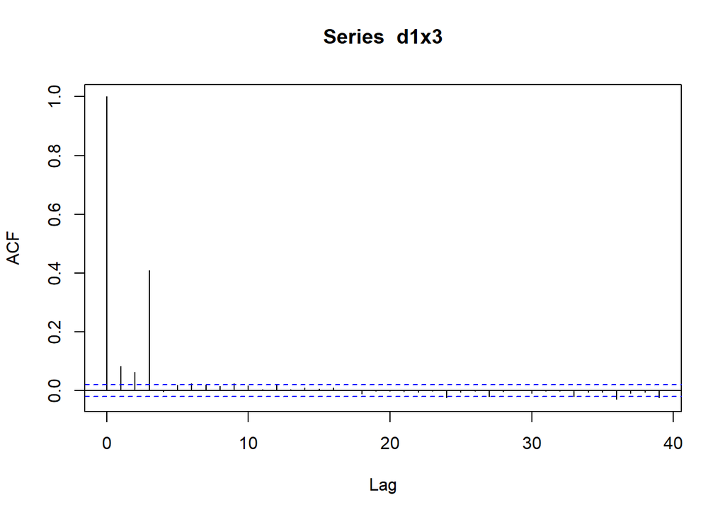

```r
acf(d1x3)
```

primero la diferenciamos una vez, observamos que la grafica esta dentro de un rango su autocorrelacion decae rapidamente y por la prueba tenemos que p es 0.01 < 0.05 por tanto estacionario

### c

3. Concluye que la serie es integrada de orden d, I(d). ¿Cu´al es el valor de d?

La serie original requiere 1 diferenciaciones para volverse estacionaria, por lo que es integrada de orden **1**, denotada como **I(1)**